# Reproducible Research. Assignment 1

This assignment makes use of data from a personal activity monitoring device. This device collects data at 5 minute intervals through out the day. The data consists of two months of data from an anonymous individual collected during the months of October and November, 2012 and include the number of steps taken in 5 minute intervals each day.

Data. Dataset: Activity monitoring data [52K] The variables included in this dataset are: steps: Number of steps taking in a 5-minute interval (missing values are coded as NA) date: The date on which the measurement was taken in YYYY-MM-DD format interval: Identifier for the 5-minute interval in which measurement was taken

Loading and preprocessing the data.

```r
library(datasets)
library(dplyr)
setwd("~/Google Drive/Data")
data = read.csv("activity.csv")
data <- as.data.frame(data)
names(data)
```

```
## [1] "steps"    "date"     "interval"
```

```r
str(data)
```

```
## 'data.frame':    17568 obs. of  3 variables:
##  $ steps   : int  NA NA NA NA NA NA NA NA NA NA ...
##  $ date    : Factor w/ 61 levels "01/10/12","01/11/12",..: 1 1 1 1 1 1 1 1 1 1 ...
##  $ interval: int  0 5 10 15 20 25 30 35 40 45 ...
```

```r
summary(data)
```

```
##      steps              date          interval
##  Min.   :  0.00   01/10/12:  288   Min.   :   0.0
##  1st Qu.:  0.00   01/11/12:  288   1st Qu.: 588.8
##  Median :  0.00   02/10/12:  288   Median :1177.5
##  Mean   : 37.38   02/11/12:  288   Mean   :1177.5
##  3rd Qu.: 12.00   03/10/12:  288   3rd Qu.:1766.2
##  Max.   :806.00   03/11/12:  288   Max.   :2355.0
##  NA's   :2304     (Other) :15840
```

I. What is mean total number of steps taken per day?. 1. Make a histogram of the total number of steps taken each day.

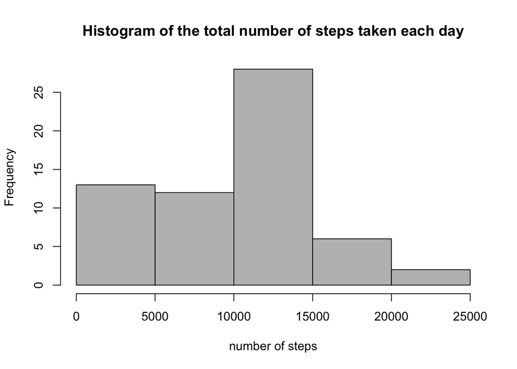

```r
dataset <- tapply(data$steps, data$date, sum, na.rm = TRUE, simplify = TRUE)
hist(dataset, xlab = "number of steps", main = "Histogram of the total number of steps taken each day", col = "gray")
```

2. Calculate and report the mean and median total number of steps taken per day

```r
mean(dataset) # mean of total number of steps taken per day
```

```
## [1] 9354.23
```

```r
median(dataset) # median of total number of steps taken per day
```

```
## [1] 10395
```

```r
na <- sum(is.na(data$steps))
na
```

```
## [1] 2304
```

2. What is the average daily activity pattern?
1. Make a time series plot (i.e. type = “l”) of the 5-minute interval (x-axis) and the average number of steps taken, averaged across all days (y-axis)

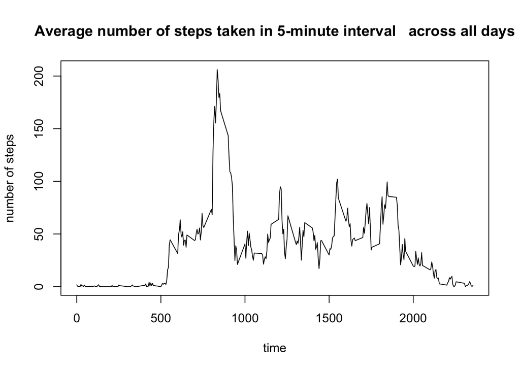

```r
  activity_interval <- as.factor(data$interval)
  step_average <- aggregate(steps ~ interval, data, FUN = mean)
   plot( step_average, type = "l", xlab = "time",
       ylab = "number of steps", main = "Average number of steps taken in 5-minute interval   across all days")
```

2. Which 5-minute interval, on average across all the days in the dataset, contains the maximum number of steps?

```r
  step_average$interval[which.max(step_average$steps)]
```

```
## [1] 835
```

```r
  na <- sum(is.na(data$steps))
  na
```

```
## [1] 2304
```

```r
original_data <- data
  for (i in 1:length(data$steps)) {
    if (is.na(data$steps[i])) {
        for (j in 1:length(step_average)) {
            if (as.character(data$interval[i]) == names(step_average[j]))
                data2$steps[i] = step_average[j]
        }
    }
}
clean_data <- data
```

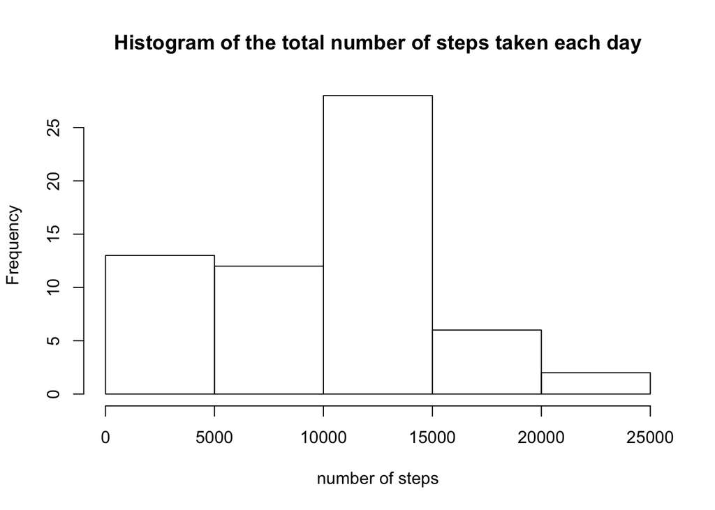

```r
steps.by.date <- tapply(clean_data$steps, clean_data$date, sum, na.rm = TRUE, simplify = TRUE)
hist(steps.by.date, xlab = "number of steps", main = "Histogram of the total number of steps taken each day")
```

```r
  mean(steps.by.date)
```

```
## [1] 9354.23
```

```r
  median(steps.by.date)
```

```
## [1] 10395
```

4. Are there differences in activity patterns between weekdays and weekends? For this part the weekdays() function may be of some help here. Use the dataset with the filled-in missing values for this part.
1. Create a new factor variable in the dataset with two levels – “weekday” and “weekend” indicating whether a given date is a weekday or weekend day.

```r
daytype <- function(date) {
    if (weekdays(as.Date(date)) %in% c("Saturday", "Sunday")) {
        "weekend"
    } else {
        "weekday"
    }
}
data$daytype <- as.factor(sapply(data$date, daytype))
```

2. Make a panel plot containing a time series plot (i.e. type = “l”) of the 5-minute interval (x-axis) and the average number of steps taken, averaged across all weekday days or weekend days (y-axis). See the README file in the GitHub repository to see an example of what this plot should look like using simulated data.

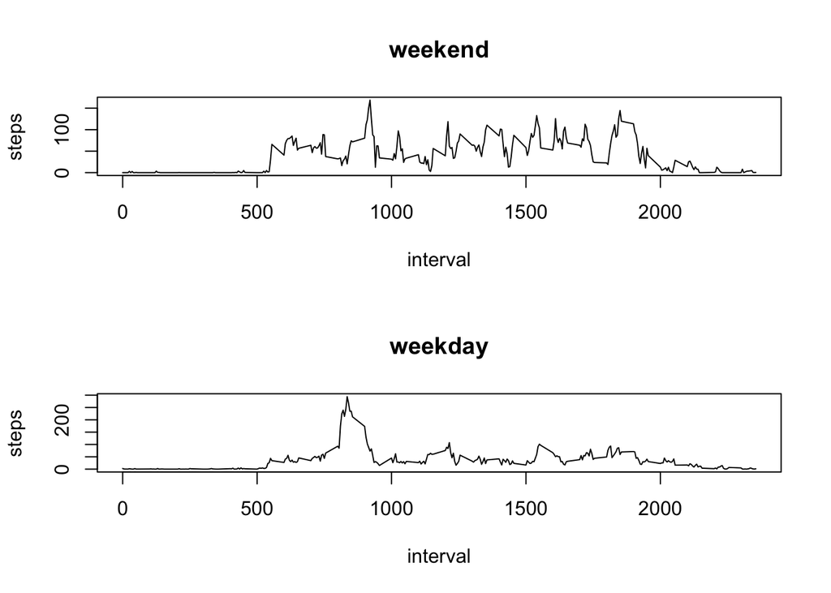

```r
par(mfrow = c(2, 1))
for (type in c("weekend", "weekday")) {
    steps.type <- aggregate(steps ~ interval, data, subset = data$daytype ==
        type, FUN = mean)
    plot(steps.type, type = "l", main = type)
}
```